# EDA Code Notebook Draft

### Individual Stats

In order to display rookies’ performances categoraized by their positions and see their performance trend in 3 continous years, we need to first modify our data frames again. We want to first further split the data frames according to the positions of rookie players, then merge data frames of different seasons together so that we are able to visualize the trends of rookie’s performance in 3 years.

```r
# Add a new variable named `year` for combining the data frames in the future
f_stat_2020_1$year <- "2020"
f_stat_2020_2$year <- "2020"
f_stat_2021_1$year <- "2021"
f_stat_2021_2$year <- "2021"
f_stat_2022_1$year <- "2022"
f_stat_2022_2$year <- "2022"

# Create function to filter rookie players into subsets according to their positions
f_pos_stat <- function(dataset, variable_name){
  dataset %>%
    filter(Pos == variable_name)
}

# Apply functions to create new data frames
# `_1` and `_2` in variable names indicate first round and second round
# `_pg`, `_c`, `_pf`, `_sg` and `_sf` in variable names indicate the five positions in basketball
f_2020_1_pg <- f_pos_stat(f_stat_2020_1, "PG")
f_2020_1_c <- f_pos_stat(f_stat_2020_1, "C")
f_2020_1_pf <- f_pos_stat(f_stat_2020_1, "PF")
f_2020_1_sg <- f_pos_stat(f_stat_2020_1, "SG")
f_2020_1_sf <- f_pos_stat(f_stat_2020_1, "SF")

f_2020_2_pg <- f_pos_stat(f_stat_2020_2, "PG")
f_2020_2_c <- f_pos_stat(f_stat_2020_2, "C")
f_2020_2_pf <- f_pos_stat(f_stat_2020_2, "PF")
f_2020_2_sg <- f_pos_stat(f_stat_2020_2, "SG")
f_2020_2_sf <- f_pos_stat(f_stat_2020_2, "SF")

f_2021_1_pg <- f_pos_stat(f_stat_2021_1, "PG")
f_2021_1_c <- f_pos_stat(f_stat_2021_1, "C")
f_2021_1_pf <- f_pos_stat(f_stat_2021_1, "PF")
f_2021_1_sg <- f_pos_stat(f_stat_2021_1, "SG")
f_2021_1_sf <- f_pos_stat(f_stat_2021_1, "SF")

f_2021_2_pg <- f_pos_stat(f_stat_2021_2, "PG")
f_2021_2_c <- f_pos_stat(f_stat_2021_2, "C")
f_2021_2_pf <- f_pos_stat(f_stat_2021_2, "PF")
f_2021_2_sg <- f_pos_stat(f_stat_2021_2, "SG")
f_2021_2_sf <- f_pos_stat(f_stat_2021_2, "SF")

f_2022_1_pg <- f_pos_stat(f_stat_2022_1, "PG")
f_2022_1_c <- f_pos_stat(f_stat_2022_1, "C")
f_2022_1_pf <- f_pos_stat(f_stat_2022_1, "PF")
f_2022_1_sg <- f_pos_stat(f_stat_2022_1, "SG")
f_2022_1_sf <- f_pos_stat(f_stat_2022_1, "SF")

f_2022_2_pg <- f_pos_stat(f_stat_2022_2, "PG")
f_2022_2_c <- f_pos_stat(f_stat_2022_2, "C")
f_2022_2_pf <- f_pos_stat(f_stat_2022_2, "PF")
f_2022_2_sg <- f_pos_stat(f_stat_2022_2, "SG")
f_2022_2_sf <- f_pos_stat(f_stat_2022_2, "SF")

# Merge data frames of different seasons together to create new data frames with `rbind()`
merged_1_pg <- rbind(f_2020_1_pg, f_2021_1_pg, f_2022_1_pg)
merged_1_c <- rbind(f_2020_1_c, f_2021_1_c, f_2022_1_c)
merged_1_pf <- rbind(f_2020_1_pf, f_2021_1_pf, f_2022_1_pf)
merged_1_sg <- rbind(f_2020_1_sg, f_2021_1_sg, f_2022_1_sg)
merged_1_sf <- rbind(f_2020_1_sf, f_2021_1_sf, f_2022_1_sf)

merged_2_pg <- rbind(f_2020_2_pg, f_2021_2_pg, f_2022_2_pg)
merged_2_c <- rbind(f_2020_2_c, f_2021_2_c, f_2022_2_c)
merged_2_pf <- rbind(f_2020_2_pf, f_2021_2_pf, f_2022_2_pf)
merged_2_sg <- rbind(f_2020_2_sg, f_2021_2_sg, f_2022_2_sg)
merged_2_sf <- rbind(f_2020_2_sf, f_2021_2_sf, f_2022_2_sf)
```

Now we are ready to visualize the new data frames we just created.

#### First Round vs Second Round Point Guards

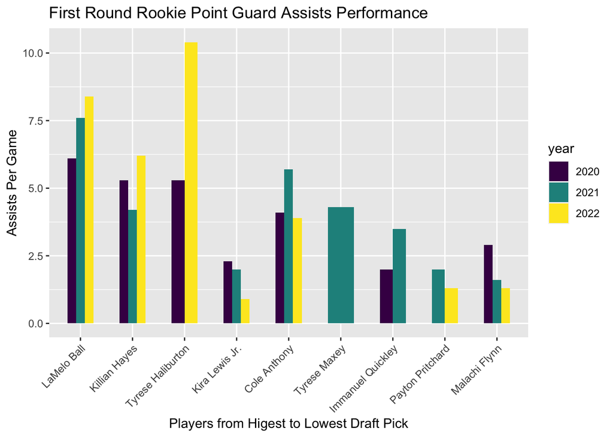

```r
# Create bar chart for first round rookies who registered as point guards
# Creating levels allows x-axis to present player names in the order of draft picks (from left to right)

levels1 <- c("Anthony Edwards","James Wiseman","LaMelo Ball","Patrick Williams","Isaac Okoro","Onyeka Okongwu","Killian Hayes","Obi Toppin","Deni Avdija","Jalen Smith","Devin Vassell","Tyrese Haliburton","Kira Lewis Jr.","Aaron Nesmith","Cole Anthony","Isaiah Stewart","Aleksej Pokusevski","Josh Green","Saddiq Bey","Precious Achiuwa","Tyrese Maxey","Zeke Nnaji","Leandro Bolmaro","R.J. Hampton","Immanuel Quickley","Payton Pritchard","Udoka Azubuike","Jaden McDaniels","Malachi Flynn","Desmond Bane")

plot_1_pg <- ggplot(merged_1_pg, aes(fill = year, x = factor(Player, levels = levels1), y = AST)) +
  geom_bar(position = "dodge", stat = "identity", width = 0.5) +
  scale_fill_viridis_d() +
  labs(title = "First Round Rookie Point Guard Assists Performance", x = "Players from Higest to Lowest Draft Pick", y = "Assists Per Game") +
  theme(axis.text.x = element_text(angle = 45, hjust = 1))

# Display the bar chart
print(plot_1_pg)
```

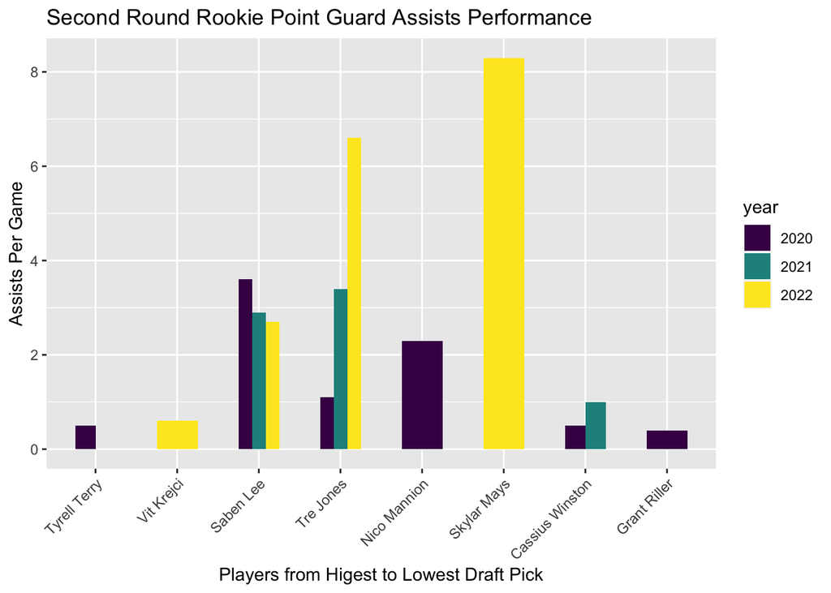

```r
# Create bar chart for second round rookies who registered as point guards
# Creating levels allows x-axis to present player names in the order of draft picks (from left to right)

levels2 <- c("Tyrell Terry", "Vernon Carey Jr.", "Daniel Oturu", "Theo Maledon", "Xavier Tillman", "Tyler Bey", "Vit Krejci", "Saben Lee", "Elijah Hughes", "Robert Woodard II", "Tre Jones", "Nick Richards", "Jahmi'us Ramsey", "Marko Simonovic", "Jordan Nwora", "CJ Elleby", "Yam Madar", "Nico Mannion", "Isaiah Joe", "Skylar Mays", "Justinian Jessup", "Kenyon Martin Jr.", "Cassius Winston", "Cassius Stanley", "Jay Scrubb", "Grant Riller", "Reggie Perry", "Paul Reed", "Jalen Harris", "Sam Merrill")

plot_2_pg <- ggplot(merged_2_pg, aes(fill = year, x = factor(Player, levels = levels2), y = AST)) +
  geom_bar(position = "dodge", stat = "identity", width = 0.5) +
  scale_fill_viridis_d() +
  labs(title = "Second Round Rookie Point Guard Assists Performance", x = "Players from Higest to Lowest Draft Pick", y = "Assists Per Game") +
  theme(axis.text.x = element_text(angle = 45, hjust = 1))

# Display the bar chart
print(plot_2_pg)
```

#### First Round vs Second Round Centers

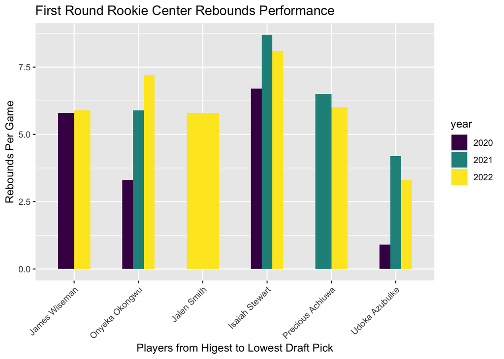

```r
# Create bar chart for first round rookies who registered as Centers
# Creating levels allows x-axis to present player names in the order of draft picks (from left to right)
plot_1_c <- ggplot(merged_1_c, aes(fill = year, x = factor(Player, levels = levels1), y = TRB)) +
  geom_bar(position = "dodge", stat = "identity", width = 0.5) +
  scale_fill_viridis_d() +
  labs(title = "First Round Rookie Center Rebounds Performance", x = "Players from Higest to Lowest Draft Pick", y = "Rebounds Per Game") +
  theme(axis.text.x = element_text(angle = 45, hjust = 1))

# Display the bar chart
print(plot_1_c)
```

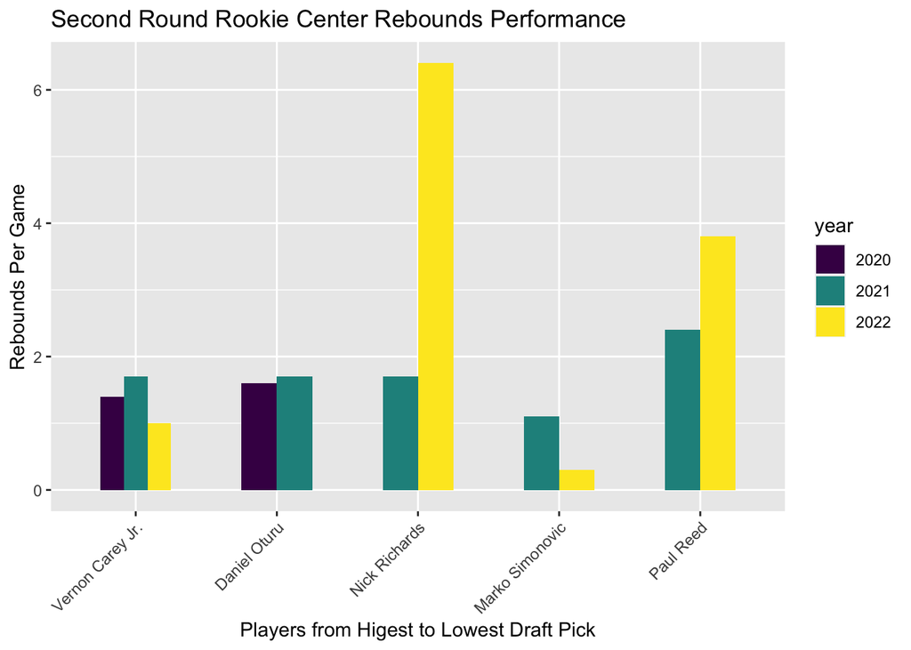

```r
# Create bar chart for second round rookies who registered as centers
# Creating levels allows x-axis to present player names in the order of draft picks (from left to right)
plot_2_c <- ggplot(merged_2_c, aes(fill = year, x = factor(Player, levels = levels2), y = TRB)) +
  geom_bar(position = "dodge", stat = "identity", width = 0.5) +
  scale_fill_viridis_d() +
  labs(title = "Second Round Rookie Center Rebounds Performance", x = "Players from Higest to Lowest Draft Pick", y = "Rebounds Per Game") +
  theme(axis.text.x = element_text(angle = 45, hjust = 1))

# Display the bar chart
print(plot_2_c)
```